# 08b_offsite_initial_modeling

2023-12-12

## QA of off-site and on-site exposure calculations

Initially lets just examine imidacloprid.

| Compound | Type | AvgRate | Units | ApplicationType | Commodity | ApplicationTiming..d. | Notes | Source | Fnote | Note | k_values | type |
| --- | --- | --- | --- | --- | --- | --- | --- | --- | --- | --- | --- | --- |
| IMIDACLOPRID | Neonicotinoid | 0.0480 | lb a.i./acre | Seed | CORN | 0 | At-plant | Douglas and Tooker | Average or standard reported rate for pest |  | 0.003629043 | Nectar |
| IMIDACLOPRID | Neonicotinoid | 0.0480 | lb a.i./acre | Seed | CORN | 0 | At-plant | Douglas and Tooker | Average or standard reported rate for pest |  | 0.003629043 | Pollen |
| IMIDACLOPRID | Neonicotinoid | 0.0500 | lb a.i./acre | Seed | SOYBEANS | 0 | At-plant | Douglas and Tooker | Average or standard reported rate for pest |  | 0.003629043 | Nectar |
| IMIDACLOPRID | Neonicotinoid | 0.0500 | lb a.i./acre | Seed | SOYBEANS | 0 | At-plant | Douglas and Tooker | Average or standard reported rate for pest |  | 0.003629043 | Pollen |
| IMIDACLOPRID | Neonicotinoid | 0.0975 | lb a.i./acre | FoliarI | SOYBEANS | 49 | Emergence | Label, 4F | Average or standard reported rate for pest |  | 0.003629043 | Nectar |
| IMIDACLOPRID | Neonicotinoid | 0.0975 | lb a.i./acre | FoliarI | SOYBEANS | 49 | Emergence | Label, 4F | Average or standard reported rate for pest |  | 0.003629043 | Pollen |
| IMIDACLOPRID | Neonicotinoid | 0.5625 | lb a.i./acre | Soil | SOYBEANS | 0 | At-Plant | Label, 4F | Average or standard reported rate for pest | Sub for cotton | 0.003629043 | Nectar |
| IMIDACLOPRID | Neonicotinoid | 0.5625 | lb a.i./acre | Soil | SOYBEANS | 0 | At-Plant | Label, 4F | Average or standard reported rate for pest | Sub for cotton | 0.003629043 | Pollen |

## Imidacloprid foliar application rates

The (USEPA) maximum cumulative labeled use of imidacloprid across all application types is 0.5 lb a.i./acre/year.

Douglas provides annual loading rates (2004-2017) for for the state of Illinois. Corn ranges from 0.0000188 (2013) to 0.001503 (2005) and soybeans range from 0.0000517 (2007) to 0.019489 (2010). These estimates do not seem to discriminate based on application type. Presumably these estiamtes average in non-treated fields.

Foliar application rates are 0.0975 lb a.i./acre for soybeans. This converts to a rate of 0.11 kg/ha. Foliar applications on corn have been largely replaced by seed treatment. The EFSA Journal report (2013) documenting discontinuing imidacloprid gives a maximum application rate for corn of 0.125 kg/ha.

## Imidacloprid seed treatment application rates

Seed treatment application rates are 0.048 lb a.i./acre for corn and 0.05 lb a.i./acre for soybeans.

Canada 2021 application rate restrictions: seed treatment for field corn, to 13 grams of active ingredient (g a.i.) per 80,000 seeds; seed treatment for sweet corn, to 67.2 g a.i. per 100 kg of seed; seed treatment for soybean, to 62.5 g a.i. per 100 kg of seed;

## Imidacloprid soil treatment application rates

| Compound | Fr | Type |
| --- | --- | --- |
| IMIDACLOPRID | 0.35 | Pollen |
| CLOTHIANIDIN | 0.69 | Pollen |
| THIAMETHOXAM | 0.69 | Pollen |
| IMIDACLOPRID | 0.017 | Nectar |
| CLOTHIANIDIN | 0.05 | Nectar |
| THIAMETHOXAM | 0.05 | Nectar |

| Compound | cf1 | cf2 | fsoil | fsurface | Hsoil | KdissSoil | KdissSurface | KelAir | KelDeg | KelGrow | Kn-L | Kp-L | KupSoil | KupSurface | LAI | LMA | Psoil | Wleaf |
| --- | --- | --- | --- | --- | --- | --- | --- | --- | --- | --- | --- | --- | --- | --- | --- | --- | --- | --- |
| BIFENTHRIN | 100 | 1000 | 0.368 | 0.467 | 0.05 | 0.1980495 | 0.792000 | 1.76e-05 | 0.21393432 | 0.035 | 0.00003480 | 4.3499477 | 0.0000000156 | 8.40e+00 | 2 | 0.08 | 1.95 | 0.8 |
| CARBARYL | 100 | 1000 | 0.368 | 0.467 | 0.05 | 0.4701419 | 1.880568 | 1.53e-02 | 0.11868959 | 0.035 | 0.39972309 | 3.1368404 | 6.2675976790 | 4.94e-03 | 2 | 0.08 | 1.95 | 0.8 |
| CARBOFURAN | 100 | 1000 | 0.368 | 0.467 | 0.05 | 0.4492867 | 1.797147 | 1.56e-02 | 0.21393432 | 0.035 | 0.41804759 | 3.0812256 | 6.5695568570 | 2.72e-03 | 2 | 0.08 | 1.95 | 0.8 |
| CHLORPYRIFOS | 100 | 1000 | 0.368 | 0.467 | 0.05 | 0.1029869 | 0.412000 | 5.54e-02 | 0.14470714 | 0.035 | 0.00987578 | 4.3351555 | 0.0177812380 | 3.95e-02 | 2 | 0.08 | 1.95 | 0.8 |
| CLOTHIANIDIN | 100 | 1000 | 0.368 | 0.467 | 0.05 | 1.8900000 | 7.556881 | 6.91e-09 | 0.04175585 | 0.035 | 0.80725592 | 0.8586181 | 9.5700000000 | 5.45e-05 | 2 | 0.08 | 1.95 | 0.8 |
| GLYPHOSATE | 100 | 1000 | 0.368 | 0.467 | 0.05 | 3.4704019 | 13.900000 | 6.16e-05 | 0.15506648 | 0.035 | 0.90116915 | 0.2533838 | 0.0000256000 | 2.56e-08 | 2 | 0.08 | 1.95 | 0.8 |
| IMIDACLOPRID | 100 | 1000 | 0.368 | 0.467 | 0.05 | 2.3453617 | 9.381447 | 4.47e-08 | 0.14145861 | 0.035 | 0.85672634 | 0.6446586 | 6.7719625830 | 2.20e-05 | 2 | 0.08 | 1.95 | 0.8 |
| THIAMETHOXAM | 100 | 1000 | 0.368 | 0.467 | 0.05 | 2.9500000 | 11.796750 | 1.33e-07 | 0.15753345 | 0.035 | 0.88018521 | 0.3487745 | 2.0200000000 | 1.82e-06 | 2 | 0.08 | 1.95 | 0.8 |

Krupke et al 2017 Journal of Applied Ecology. Neonicotinoid-containing dust deposition (N in nanograms per slide) for seed treated corn as a function of distance from the field margin (meters). x <- exp(1.68-0.0905*log(d))-1. They conclude that 42.4% of the land area within the state of Indiana may be subjected to a pulse of neonicotinoid deposition at levels of ≥1.40 ug/m2 during sowing of treated maize. They do not treat neonics individually, they sum thiomethoxam and clothianidin. They use four spatial zones (planted field, 0-30m, 30-60m, 60-90m).

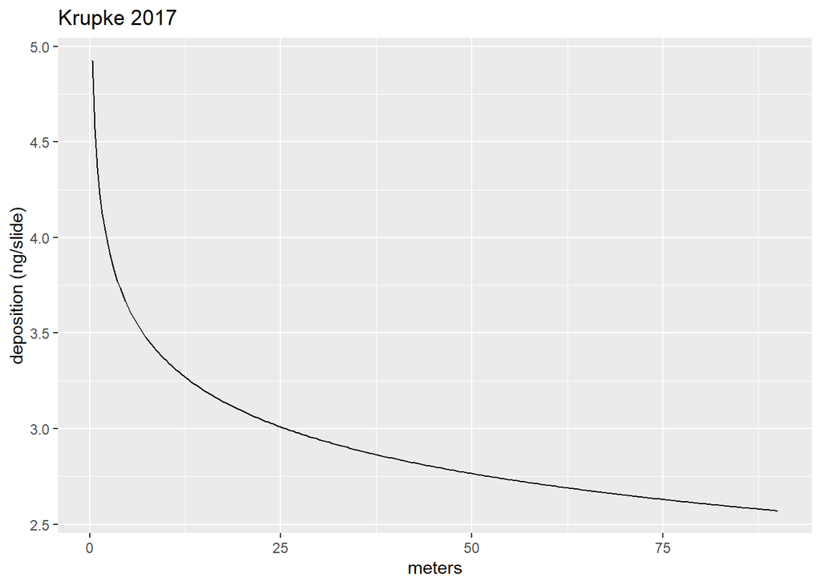

```r
######## Analysis ###########
#### Seed Applications ----
## Dust ----
#these are the only residues we'll measure as ug/m2
#First, we will derive the fraction of dust moving across and off the field
#d<-1:299*0.3048 # first, convert the distance to meters
d <- seq(1/3, 90, 1/3)
x<-exp(1.68-0.0905*log(d))-1 # estimate the fraction
krupke_df <- data.frame(dist=d, dep=x)
ggplot(krupke_df, aes(x=dist, y=dep)) +
  geom_line() +
  xlab("meters") +
  ylab("deposition (ng/slide)") +
  ggtitle("Krupke 2017")
```

The area of the glass microscope slide is (generic slide is 75 mm * 25 mm = 1875 mm2). We want to convert to ug/m2.

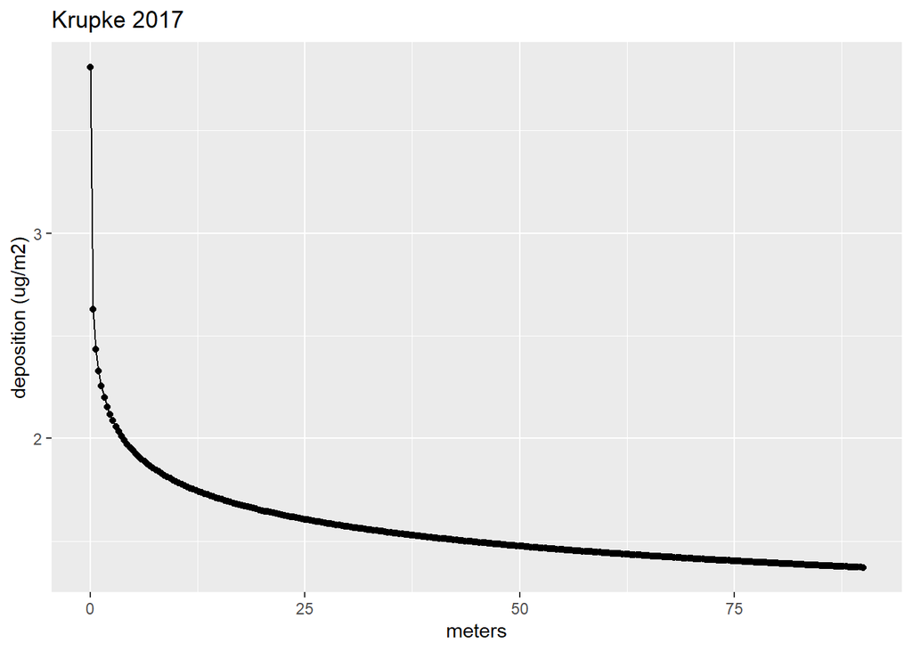

```r
# the below conversion is (x ng/1875 mm2)*(1000000 mm2/1 m2)*(1 ug/ 1000 ng) = (x/1875)*1000 to yield ug/m2
orig_conc_at_distance<-(x/1875)*1000 #ug/m2
krupke_df2 <- data.frame(dist=d, dep=orig_conc_at_distance)
krupke_df3 <- rbind(c(0,3.81),
                  krupke_df2)
ggplot(krupke_df3, aes(x=dist, y=dep)) +
  geom_point() +
  geom_line() +
  xlab("meters") +
  ylab("deposition (ug/m2)") +
  ggtitle("Krupke 2017")
```

The above plot can be compared to Krupke et al 2017 empirical data: “Using our empirical data, predicted deposition levels across the state can be further estimated given the amount of area at increasing distances from maize fields as follows: 25.3% of the state receives 3.81 ug/m2 of neonicotinoid residues in the form of planter dust, 6.6% receives 1.70 ug/m2, 5.5% receives 1.49 ug/m2, and 5.0% receives 1.40 ug/m2. These areas correspond with 30 m by 30 m parcels of land that are 0–30, 30–60, and 60–90 m from maize field margins, respectively.”

This next block calculates an average application rate for corn seed treatment for clothianidin. Check to see where the 2.06 and 11.92 come from (Krupke manuscript supplement?) and what the units are. Table S-8 of Krupke et al gives a low label rate of 0.25 mg/seed (empirical measurement 0.253 mg/seed) and a high label rate of 1.25 mg/seed (empirical measurement 1.20 mg/seed). Number of seeds per square meter?

32000 seeds per acre, 4046.856 meters per acre, equals 7.91 seeds/m2. 33000 seeds per acre, 4046.856 meters per acre, equals 8.1545 80000 kernels per hectare, 100000 mg/ha. 0.1 kg/ha.

From eap: corn seeds/acre low = 33000 corn seed/acre high = 40250 sweet corn low = 13068 sweet corn high = 26136 soybeans low = 50000 soybeans high = 130000

```r
# original conc in field, from Krupke based on seeding rate
# mg/seed * seeds/acre * acre/m2 * ug/mg = ug/m2
ug_mg <- 1000
low_clothi_seed_rate <- 0.25*(33000/4046.856) * ug_mg #2038.62
high_clothi_seed_rate <- 1.25*(40250/4046.856) * ug_mg #124324.9
#conc_in_field<-((2.06+11.92)/2)*1000 #(ug/m2) # average application rate
conc_in_field <- mean(c(low_clothi_seed_rate, high_clothi_seed_rate))
conc_in_field
```

```
## [1] 7235.555
```

Original seed treatment midpoint was 6990 ug/m2. Which is 0.000006990 kg/m2 and 0.0699 kg/ha.

Updated output for on-site seed treatment application rate is 7235.555 ug/m2.

An argument could be made to use low end of range rather than midpoint to be conservative.

This conc_in_field (actually the in-field application rate from Krupke) is used to normalize the other off-field deposition rates to give a percentage that can be leverage to estimate off-field deposition rates for (non-clothi) pesticides. Also, reread Krupke et al 2017 to see if they say what rates they used to generate the empirical data.

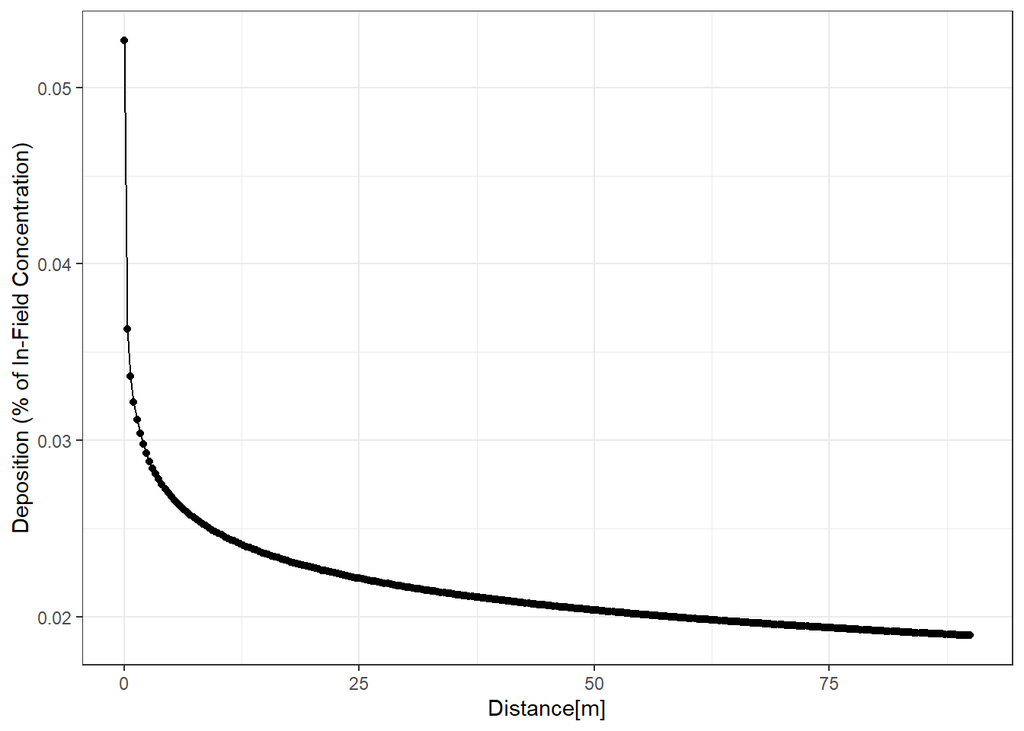

```r
#to translate this relationship to other in-field concentrations,
#I assume that the fraction of off-site deposition based on the original concentration is reflective of all seed treatments
deposition<-(orig_conc_at_distance/conc_in_field) #proportion of off/on deposition rate for each distance = ug/m2 (deposition(d))/ug/m2 (applied on-site)
air_krupke<-as.data.frame(cbind(d,orig_conc_at_distance, deposition))
# avg_frac<-(0.001849+0.000319)/2 not sure where these numbers are from
avg_frac <- 3.81/conc_in_field

#add in the initial estimate of the concentration at 0 (in-field)
# 3.81 ug/m2 is mentioned in Krupke as the on-field deposition rate for clothianidin.
air_krupke<-rbind(c(0,3.81,avg_frac),
                  air_krupke)

#air krupke represents a dataframe with information about the on and off-field estimate of deposition from seeds, based on the #relationship
#between the concentration in field in ug/m2 and the amount reported offsite. we then use these deposition fractions to estimate the same #relationship for other compounds

#visualize the original concentration, if desired
p <- ggplot(air_krupke, aes(d, deposition*100)) +
   geom_point()+
   geom_line()+
   ylab("Deposition (% of In-Field Concentration)")+
   xlab("Distance[m]")+
   theme_bw()
p
```

This graph can be used to give deposition percentages of off-site deposition rate to on-site application rate for each of the 3 pixel distances (0-30m, 30-60m, 60-90m).

```r
first_pixel_deposition_fraction <- mean(air_krupke$deposition[1:90])
first_pixel_deposition_fraction
```

```
## [1] 0.0002481087
```

```r
second_pixel_deposition_fraction <- mean(air_krupke$deposition[91:180])
second_pixel_deposition_fraction
```

```
## [1] 0.0002071571
```

```r
third_pixel_deposition_fraction <- mean(air_krupke$deposition[181:270])
third_pixel_deposition_fraction
```

```
## [1] 0.0001940998
```

Krishnan et al 2020 (https://setac.onlinelibrary.wiley.com/doi/10.1002/etc.4672) provides Agdrift based point deposition values as a function of distance for imidacloprid in Table S5.